# Supervised Learning - Regression Trees and Bagging

# [Bagging](https://www.r-bloggers.com/improve-predictive-performance-in-r-with-bagging/)

- Single tree models suffer from high variance, they are highly unstable and poor predictors.
- [**Pruning**](https://en.wikipedia.org/wiki/Decision_tree_pruning) helps, but there are alternative methods that exploite the variability of single trees in a way that can significantly improve performance.
- Bootstrap aggregating (bagging) is one such approach (originally proposed by Breiman, 1996).
- Bagging is a method for combining predictions from different regression or classification models.
- The results of the models are then averaged - in the simplest case model predictions are included with the same weight.
- The weights could depend on the quality of the model prediction, i.e. “good” models are more important than “bad” models.
- Bagging leads to significantly improved predictions in the case of unstable models.

# Bagging follows three simple steps:

- 1.) Create $m$ bootstrap samples from the training data. Bootstrapped samples allow us to create many slightly different data sets but with the same distribution as the overall training set.
- 2.) For each bootstrap sample train a single, unpruned regression tree.
- 3.) Average individual predictions from each tree to create an overall average predicted value.

# The bagging process.

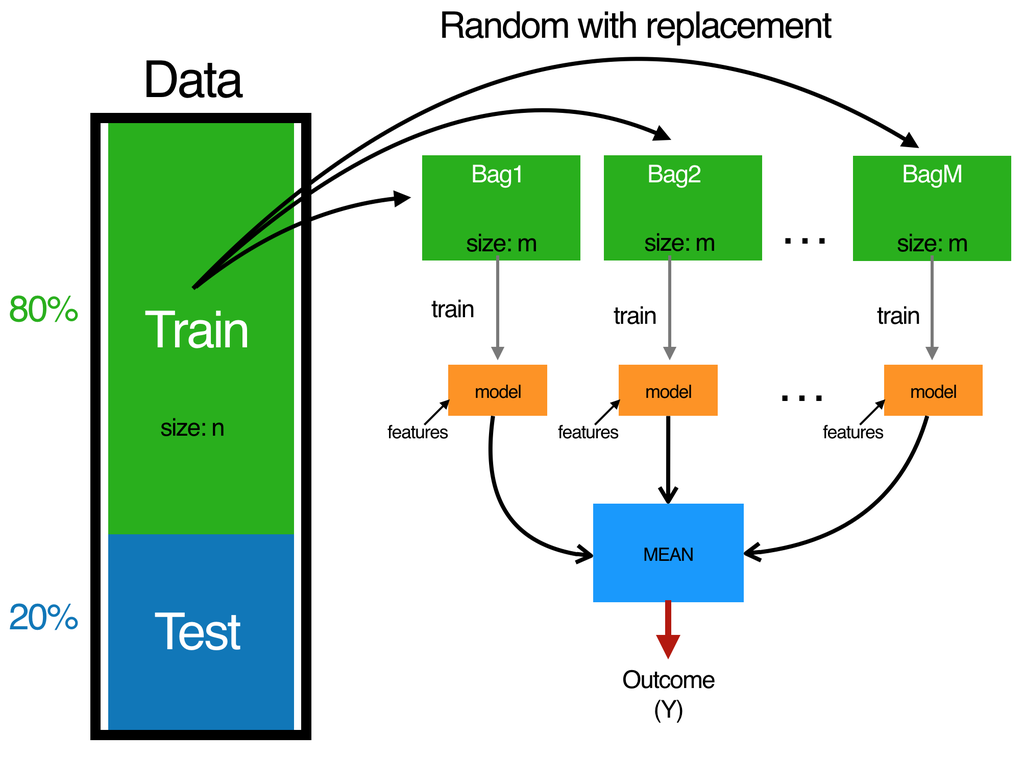

# About bagging

- This process can be applied to any regression or classification model;
- It provides the greatest improvement for models that have high variance.
- More stable parametric models such as linear regression and multi-adaptive regression splines tend to experience less improvement in predictive performance.
- On average, a bootstrap sample will contain 63 per cent of the training data.
- This leaves about 33 per cent ($\dfrac{1}{3}$) of the data out of the bootstrapped sample. We call this the out-of-bag (OOB) sample.
- We can use the OOB observations to estimate the model’s accuracy, creating a natural cross-validation process.

# Bagging with `ipred`

- Fitting a bagged tree model is quite simple.
- Instead of using `rpart` we use `ipred::bagging`.
- We use `coob = TRUE` to use the OOB sample to estimate the test error.

# Train bagged model

```r
set.seed(123)
(bagged_m1 <- bagging(formula = Sale_Price ~ .,
  data    = ames_train,coob= TRUE))
```

```
##
## Bagging regression trees with 25 bootstrap replications
##
## Call: bagging.data.frame(formula = Sale_Price ~ ., data = ames_train,
##     coob = TRUE)
##
## Out-of-bag estimate of root mean squared error:  36991.67
```

# Things to note typically

- The more trees the better - we are averaging over more high variance single trees.
- We see a dramatic reduction in variance (and hence our error) and eventually the reduction in error will flatline
- You need less than 50 trees to stabilize the error.

# Number of bootstrap samples

- By default bagging performs 25 bootstrap samples and trees but we may require more.

```r
# assess 10-50 bagged trees
ntree <- 10:50
# create empty vector to store OOB RMSE values
rmse <- vector(mode = "numeric", length = length(ntree))
for (i in seq_along(ntree)) {
  # reproducibility
  set.seed(123)
  # perform bagged model
  model <- bagging(formula = Sale_Price ~ .,
  data=ames_train,coob= TRUE,nbagg=ntree[i]
)
  # get OOB error
  rmse[i] <- model$err
}
```

# Plot the result

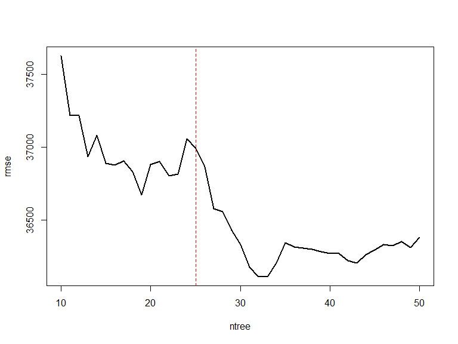

```r
plot(ntree, rmse, type = 'l', lwd = 2)
abline(v = 25, col = "red", lty = "dashed")
```

# Bagging with `caret`

- Bagging with `ipred` is simple but there are some additional benefits of bagging with `caret`.

1.) Its easier to perform cross-validation. Although we can use the OOB error, performing cross validation will provide a more robust understanding of the true expected test error.

2.) We can assess [**variable importance**](https://topepo.github.io/caret/variable-importance.html) across the bagged trees.

# [Excursus: Variable importance (vi)](https://cran.r-project.org/web/packages/datarobot/vignettes/VariableImportance.html)

- vi measures help understand the results obtained from complex machine learning models
- There is no general consensus on the “best” way to compute - or even define - the concept of variable importance.
- See a list of many possible approaches to compute vi in the help file of the command `varImp`

```r
?caret::varImp
```

- vi refers to how much a given model “uses” that variable to make accurate predictions. The more a model relies on a variable to make predictions, the more important it is for the model.

# A 10-fold cross-validated model.

```r
# Specify 10-fold cross validation
ctrl <- trainControl(method = "cv",  number = 10)

bagged_cv <- train(Sale_Price ~ .,data = ames_train,
  method = "treebag",trControl = ctrl,importance = TRUE)
```

- `treebag`- means we use a bagging tree

# Assess results

```r
bagged_cv
```

```
## Bagged CART
##
## 2051 samples
##   80 predictor
##
## No pre-processing
## Resampling: Cross-Validated (10 fold)
## Summary of sample sizes: 1846, 1845, 1846, 1845, 1847, 1847, ...
## Resampling results:
##
##   RMSE      Rsquared   MAE
##   35854.02  0.8009063  23785.85
```

# Assess results with a plot (top 20 variables)

- Here, variable importance is measured by assessing the total amount SSE is decreased by splits over a given predictor, averaged over all $m$ trees.

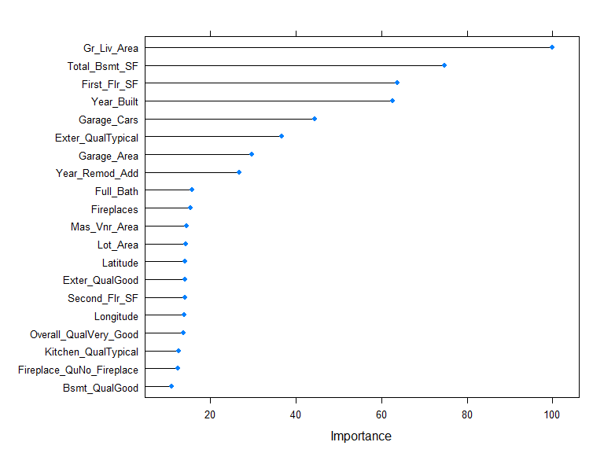

```r
plot(varImp(bagged_cv), 20)
```

# Extensions

- If we compare this to the test set out of sample we see that our cross-validated error estimate was very close.

```r
pred <- predict(bagged_cv, ames_test)
RMSE(pred, ames_test$Sale_Price)
```

```
## [1] 35357.89
```

- We have successfully reduced our error to about $35k;
- Extensions of this bagging concept (random forests and GBMs) can significantly reduce this further.

# [Decision Trees](http://www.statmethods.net/advstats/cart.html)

[Regression tree vs. classification tree](http://www.statmethods.net/advstats/cart.html)

```r
library(rpart)
```

Grow a tree

```r
fit <- rpart(Kyphosis ~ Age + Number + Start,
   method="class", data=kyphosis)

printcp(fit) # display the results
```

```
##
## Classification tree:
## rpart(formula = Kyphosis ~ Age + Number + Start, data = kyphosis,
##     method = "class")
##
## Variables actually used in tree construction:
## [1] Age   Start
##
## Root node error: 17/81 = 0.20988
##
## n= 81
##
##         CP nsplit rel error xerror    xstd
## 1 0.176471      0   1.00000 1.0000 0.21559
## 2 0.019608      1   0.82353 1.1176 0.22433
## 3 0.010000      4   0.76471 1.1176 0.22433
```

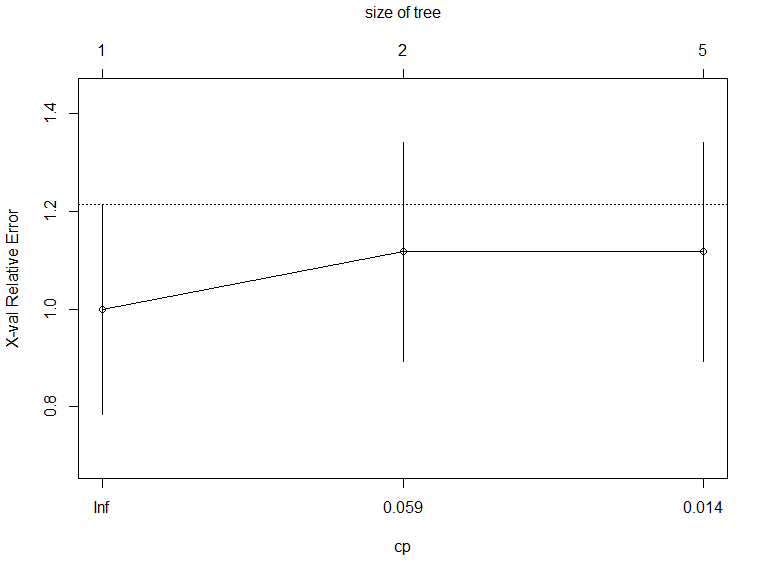

```r
plotcp(fit) # visualize cross-validation results
```

```r
summary(fit) # detailed summary of splits
```

```
## Call:
## rpart(formula = Kyphosis ~ Age + Number + Start, data = kyphosis,
##     method = "class")
##   n= 81
##
##           CP nsplit rel error   xerror      xstd
## 1 0.17647059      0 1.0000000 1.000000 0.2155872
## 2 0.01960784      1 0.8235294 1.117647 0.2243268
## 3 0.01000000      4 0.7647059 1.117647 0.2243268
##
## Variable importance
##  Start    Age Number
##     64     24     12
##
## Node number 1: 81 observations,    complexity param=0.1764706
##   predicted class=absent   expected loss=0.2098765  P(node) =1
##     class counts:    64    17
##    probabilities: 0.790 0.210
##   left son=2 (62 obs) right son=3 (19 obs)
##   Primary splits:
##       Start  < 8.5  to the right, improve=6.762330, (0 missing)
##       Number < 5.5  to the left,  improve=2.866795, (0 missing)
##       Age    < 39.5 to the left,  improve=2.250212, (0 missing)
##   Surrogate splits:
##       Number < 6.5  to the left,  agree=0.802, adj=0.158, (0 split)
##
## Node number 2: 62 observations,    complexity param=0.01960784
##   predicted class=absent   expected loss=0.09677419  P(node) =0.7654321
##     class counts:    56     6
##    probabilities: 0.903 0.097
##   left son=4 (29 obs) right son=5 (33 obs)
##   Primary splits:
##       Start  < 14.5 to the right, improve=1.0205280, (0 missing)
##       Age    < 55   to the left,  improve=0.6848635, (0 missing)
##       Number < 4.5  to the left,  improve=0.2975332, (0 missing)
##   Surrogate splits:
##       Number < 3.5  to the left,  agree=0.645, adj=0.241, (0 split)
##       Age    < 16   to the left,  agree=0.597, adj=0.138, (0 split)
##
## Node number 3: 19 observations
```

[output cut: 31 more lines]

```
##   left son=22 (14 obs) right son=23 (7 obs)
##   Primary splits:
##       Age    < 111  to the right, improve=1.71428600, (0 missing)
##       Start  < 12.5 to the right, improve=0.79365080, (0 missing)
##       Number < 3.5  to the right, improve=0.07142857, (0 missing)
##
## Node number 22: 14 observations
##   predicted class=absent   expected loss=0.1428571  P(node) =0.1728395
##     class counts:    12     2
##    probabilities: 0.857 0.143
##
## Node number 23: 7 observations
##   predicted class=present  expected loss=0.4285714  P(node) =0.08641975
##     class counts:     3     4
##    probabilities: 0.429 0.571
```

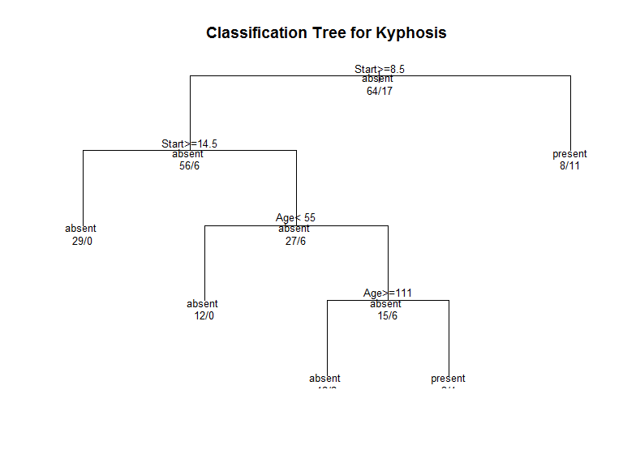

```r
# plot tree
plot(fit, uniform=TRUE,
   main="Classification Tree for Kyphosis")
text(fit, use.n=TRUE, all=TRUE, cex=.8)
```

[Decision Trees and Random Forest](https://cran.r-project.org/doc/contrib/Zhao_R_and_data_mining.pdf)

# Resources and links

- Breimann (1984) - [**Classification and Regression Trees**](https://www.amazon.com/Classification-Regression-Wadsworth-Statistics-Probability/dp/0412048418)
- [**Vignette**](https://cran.r-project.org/web/packages/partykit/vignettes/ctree.pdf) for package `partykit`
- [**Conditional Inference Trees**](https://rpubs.com/awanindra01/ctree)
- [**Conditional inference trees vs traditional decision trees**](https://stats.stackexchange.com/questions/12140/conditional-inference-trees-vs-traditional-decision-trees)
- [Video on tree based methods](https://www.youtube.com/watch?v=6ENTbK3yQUQ)
- [An example of practical machine learning using R](https://rstudio-pubs-static.s3.amazonaws.com/64455_df98186f15a64e0ba37177de8b4191fa.html)